# Pilot import and analyses

This page offers some additional code and examples for manipulating the pilot survey data.

As always, you’ll want to load the `RCPA3` package at the start of your analysis so you can use the commands from the workbook:

```r
library(RCPA3)
```

# Importing the data

The results of the pilot analysis are stored on github in a `.rds` file, so before you can use them, you’ll need import these into R. Since the files are hosted online, you can access them from within R by just running the code below:

```r
# this string is just a link to a web page that holds the data:
loc <- url('https://github.com/Neilblund/GVPT-201-Site/raw/refs/heads/main/Rdata/pilot_fmted.rds')

# read RDS reads the data from the URL into R:
pilot<-readRDS(loc)
```

Note that I’m assigning the data to a variable called `pilot`, so I can access specific columns using the `pilot$[some column name]`. For example:

```r
pilot$Q4
```

```
 [1] Some college, but no degree High school diploma or GED
 [3] Some college, but no degree Some college, but no degree
 [5] High school diploma or GED  High school diploma or GED
 [7] Some college, but no degree Some college, but no degree
 [9] High school diploma or GED  <NA>
7 Levels: Some high school or less ... Prefer not to say
```

## Applying a new variable label

The pilot data set includes the exact wording of each question as a variable label. You’ll see these automatically when you use functions like `freqC`, but you can also view them by using `Hmisc::label(variable_name)`[^1]

```r
Hmisc::label(pilot$Q6)
```

```
[1] "How old are you (in years)?"
```

If you have created a new variable, or if you want to replace an existing label with something shorter, you can just use `Hmisc::label(varname) <- "New label"`. For example, the label for `Q19_1` is really long and might not even fit on a plot, so I can assign a new shorter label to it like this:

```r
Hmisc::label(pilot$Q19_1) <- "Support for electing president by popular vote"
```

And now we can view the label again to check that our code worked:

```r
Hmisc::label(pilot$Q19_1)
```

```
[1] "Support for electing president by popular vote"
```

# Recoding Variables

There are likely a number of cases where you will want to remove, collapse, or reorder categories of a survey response. There are a variety of methods for doing this kind of operation, and it can be a little tricky. If you’re looking for more guidance you should consult Chapter 3 of your workbook.

## Dropping levels

Many of the survey questions allow responses that are mostly ordinal except for a “Not sure” response that shows up as a final response option. Leaving this “Not sure” option in place breaks the ordering of our otherwise ordinal question, so we’ll often treat these answers as `NA` values (or combine them with another category)

For instance, `Q37` asks respondents to rank their own political views on a scale from `Far left` to `Far right`, but a small number of respondents said they were `Not sure` where they fit on this scale. We’ll generally want to drop or reassign these responses so we can treat `Q37` as an ordered variable.

```r
levels(pilot$Q37)
```

```
[1] "Far left"     "Left"         "Center-left"  "Center"       "Center-right"
[6] "Right"        "Far right"    "Not sure"
```

One way we can get rid of these “Not sure” responses is by creating a new factor variable that doesn’t include “Not sure” as a valid level. This will cause those responses to automatically become `NA` values, which we can then easily ignore when we run a calculation on Q37.

In plain English, the code below is saying:

“Make a new column in the pilot dataframe called ‘lr_position’. The new variable will be an ordered factor variable with all the same levels from Q37 except for ‘Not sure’”

```r
# The same levels in the SAME ORDER they appear when I run levels(pilot$Q37)
newlevels <- c("Far left", "Left", "Center-left", "Center", "Center-right", "Right","Far right")

pilot$lr_position <- factor(x=pilot$Q37,
                            ordered =TRUE,
                            levels = newlevels)
```

Note here that there are now zero “Not sure” responses:

```r
# table just makes a simple frequency table
levels(pilot$lr_position)
```

```
[1] "Far left"     "Left"         "Center-left"  "Center"       "Center-right"
[6] "Right"        "Far right"
```

This kind of recoding is easy to mess up, so its always a good idea to check your results after you finish. You can use `View(pilot)` to bring up the data viewer and browse your results, or you can use `freqC` to get a frequency table, or just use the basic `table` function and check to make sure your results match your expectations.

```r
table(pilot$Q37)  # 9 not sure responses
```

```
    Far left         Left  Center-left       Center Center-right        Right
          27           88           64           22           34           12
   Far right     Not sure
           3            9
```

```r
table(pilot$lr_position)  # the not sure responses are absent here, but everything else is identical
```

```
    Far left         Left  Center-left       Center Center-right        Right
          27           88           64           22           34           12
   Far right
           3
```

## Combining levels

In some cases we may want to simplify our analyses by combining certain categories of a response. For instance, only 3 respondents said that social media had an “Extremely positive” effect on politics. This might not be enough people for a meaningful inference, so we could decide to collapse this five category response into three categories: negative, neutral, and positive.

Do believe that social media has a positive or negative influence on American politics?

| Q52 | n | percent | cumulative percent |
| --- | --- | --- | --- |
| Extremely negative | 44 | 17.1% | 17.1% |
| Somewhat negative | 131 | 50.8% | 67.8% |
| Neither positive nor negative | 53 | 20.5% | 88.4% |
| Somewhat positive | 27 | 10.5% | 98.8% |
| Extremely positive | 3 | 1.2% | 100.0% |

Conceptually, I want to do a transformation that remaps the values like this:

- Extremely negative → negative
- Somewhat negative → negative
- Neither positive nor negative → neutral
- Somewhat positive → positive
- Extremely positive → positive

There are actually several ways to do this. I’ve put several options in the tab below.

**Using logical statements**

We can use boolean operators to selectively assign values to a vector and then declare that vector as a factor variable. To make this work, I’ll start with an empty factor called `socmed_fx` and then I’ll assign values to the column based on the current value of `Q52`.

In plain English, that first line of assigning values means “if `pilot$Q52` is”Extremely negative” then `pilot$socmed_fx` should be “negative”

```r
# creating an empty factor variable with all the levels I intend to include in order
pilot$socmed_fx <- factor(NA, levels=c('negative',"neutral", "positive"), ordered=TRUE)

# assigning values
pilot$socmed_fx[pilot$Q52 == "Extremely negative"] <- "negative"
pilot$socmed_fx[pilot$Q52 == "Somewhat negative"]  <- "negative"
pilot$socmed_fx[pilot$Q52 == "Neither positive nor negative"] <- "neutral"
pilot$socmed_fx[pilot$Q52 == "Somewhat positive"]  <- "positive"
pilot$socmed_fx[pilot$Q52 == "Extremely positive"] <- "positive"
```

**Using factor() with labels =**

We can also use the `factor` function to perform this re-mapping. In some cases this can be a little more concise but you have to pay very close attention to the ordering of your original factor variable.

To make this work, I’m going to create a vector called `new_labels` that lists, **in order**, the new label that we want to assign to each old value of `Q52`. Once I’ve got this, I’ll run `factor` again, and include `labels = new_labels` to assign the new value labels to my new factor variable.

```r
new_labels <- c("negative", "negative", "neutral", "positive", "positive")

pilot$socmed_fx <- factor(x=pilot$Q52,
                          labels = new_labels,
                          ordered =TRUE

                            )
```

**Using the forcats package**

Finally, if you’re comfortable with installing and loading R packages, the `forcats` package has a nice alternative method for doing this kind of recode that might be a little more intuitive. The function is called `fct_recode` and the syntax will just be `fct_recode(old_variable, "new label" = "old label" ...)`. Here’s an example:

```r
# remember to uncomment and then run the line below to install the package:
# install.packages('forcats')

# then you'll need to run library(forcats) each time you re-open Rstudio
# in order to load the package:

library(forcats)

pilot$socmed_fx <-fct_recode(
  pilot$Q52,
  "negative" = "Extremely negative",
  "negative" = "Somewhat negative",
  "neutral" = "Neither positive nor negative"  ,
  "positive" = "Somewhat positive" ,
  "positive" = "Extremely positive"
)
```

Regardless of what method you use, you’ll want to check your results after you do your recoding and make sure they align with your expectations:

```r
table(pilot$Q52)
```

```
           Extremely negative             Somewhat negative
                           44                           131
Neither positive nor negative             Somewhat positive
                           53                            27
           Extremely positive
                            3
```

```r
table(pilot$socmed_fx)
```

```
negative  neutral positive
     175       53       30
```

## Splitting a numeric variable

We might also want to recode numeric variables into a smaller number of categories. We can do this using the `transformC` function from the `RCPA3` package. For instance, Q34_1 - Q34_5 are all feeling thermometer variables that ask respondents to rate their level of agreement or disagreement with a set of policy proposals. What if I wanted to split `Q34_5` up into an ordered categorical variable?

We can use the `cut` option of `transformC` to cut the variable into five smaller groups:

```r
pilot$expand_scotus<-transformC(type='cut',               # use this option to cut a number into groups
                                  data=pilot,             # the data set
                                  x=Q34_5,                # the variable we're cutting
                                  cut = c(20,40,60,80),   # the cutoff points
                                  confirm=F)              # this turns off a prompt that asks us to confirm before executing the command

# checking out the values
table(pilot$expand_scotus)
```

```
[  0, 20) [ 20, 40) [ 40, 60) [ 60, 80) [ 80,100]
       44        35        59        48        37
```

Now we might also want to add some descriptive labels to this variable in order to make it a little more coherent in a plot or table. To do this we modify the `levels` attribute with a vector of labels that we want to assign to each level of the variable:

```r
levels(pilot$expand_scotus) <- c("Strongly Disagree", "Disagree", "Neutral", "Agree", "Strongly Agree")
```

```r
table(pilot$expand_scotus)
```

```
Strongly Disagree          Disagree           Neutral             Agree
               44                35                59                48
   Strongly Agree
               37
```

## Making a dummy

Finally, in some cases we’ll want to “dummy code” some variables to make them dichotomous.

One way to do this is using `transformC` with the `type='dummy'` option. Here’s an example of recoding the survey question about gender ID so that women are coded as a “1” and everyone else (including “prefer not to say” or “other”) are coded as “0”.

```r
pilot$female_dummy <- transformC(type = 'dummy',
                                 x = pilot$Q7,
                                 response = 'Female',
                                 confirm = FALSE)

# check the results:
table(pilot$female_dummy)
```

```
  0   1
108 149
```

Another way to do this is by writing a logical expression and then converting it to a numeric variable. Converting a logical expression to numeric will automatically change all `FALSE` values to zero and all `TRUE` values to one:

```r
# just an illustration! This isn't code you need to use anywhere

boolean_vect <- c(FALSE, FALSE, FALSE, TRUE, TRUE, TRUE, TRUE)

as.numeric(boolean_vect)
```

```
[1] 0 0 0 1 1 1 1
```

These two approaches are equivalent except for some additional options offered by `transformC`.

```r
pilot$female_dummy = as.numeric(pilot$Q7 =="Female")
```

And don’t forget that taking the mean of a dummy will return the proportion of “1”s in that dummy variable. So we can get the % of women respondents like this:

```r
mean(pilot$female_dummy, na.rm=T)
```

```
[1] 0.5797665
```

I could also create dummy variables for a more complex range of conditions. For instance, here’s how I could create a dummy variable that was equal to 1 for women who voted in 2024 and 0 for everyone else:

```r
pilot$female_voted_dummy = as.numeric(pilot$Q14  == "Yes" & pilot$Q7 =="Female")

table(pilot$female_voted_dummy)
```

```
  0   1
128 126
```

## Combining Variables

### Example 1: Condition based on multiple variables

What if I wanted to do something like create an indicator variable for Apple users who also use social media every day to get news about politics? I could do this by using a logical statement similar to the one I used in the section on combining variables. However, in this case, I’ll write out multiple conditions and chain them together using an `&` operator.

```r
#
pilot$sm_apple <- NA

pilot$sm_apple[pilot$Q50 == "Daily" & pilot$apple == "Apple user" ] <- "Daily SM user + Apple OS"
pilot$sm_apple[pilot$Q50 != "Daily" & pilot$apple != "Apple user" ] <- "Less than daily SM user + Non-Apple OS"
pilot$sm_apple[pilot$Q50 != "Daily" & pilot$apple == "Apple user" ] <- "Less than daily SM user + Apple user"
pilot$sm_apple[pilot$Q50 == "Daily" & pilot$apple != "Apple user" ] <- "Less than daily SM user+ Non-Apple user"

table(pilot$sm_apple)
```

```
               Daily SM user + Apple OS    Less than daily SM user + Apple user
                                     11                                      36
 Less than daily SM user + Non-Apple OS Less than daily SM user+ Non-Apple user
                                    151                                      60
```

### Example 2: Additive index

For instance, Q49_1 through Q49_5 ask about a respondent’s level of trust in various institutions. We could combine all of these questions into an additive index of “general” social trust.

There’s a number of ways we could approach this problem, but for this example, I’ll just convert this ordered factor variable into a number using `as.numeric`. Since the factor levels are already ordered from least trusting to most trusting, I can add all of these together to get a simple additive index of the level of trust expressed by each respondent:

```r
total_trust <-
  as.numeric(pilot$Q49_1)  +
  as.numeric(pilot$Q49_2)  +
  as.numeric(pilot$Q49_3)  +
  as.numeric(pilot$Q49_4) +
  as.numeric(pilot$Q49_5)


summary(total_trust)
```

```
   Min. 1st Qu.  Median    Mean 3rd Qu.    Max.    NA's
   5.00   12.00   14.00   13.64   16.00   19.00      27
```

### Example 3: Averaging

What if we want average over a set of numeric responses? For instance, we have a series of five questions that all ask people to rate Trump’s cabinet picks and advisers on a 0 to 100 scale, we might decide we want to calculate an average across all of these officials to construct a metric of “general support for the Trump administration”.

As usual, there’s more than one way to approach this problem, but here’s one solution that selects the five columns that ask about Trump’s picks, and then uses `rowMeans` to calculate the average across each row of data:

```r
# a vector of column names we want to extract:
nominee_cols<- c('Q25_1', 'Q25_2','Q25_3', 'Q25_4', 'Q25_5')

# creating a new data frame from pilot that only contains the five columns listed above:
nominees<-pilot[,nominee_cols]

# rowMeans will calculate an average across each row of the data
avg_nominees<-rowMeans(nominees, na.rm=T)

# putting the result in its own column
pilot$avg_nominees <- avg_nominees
```

Now we can take a look at the distribution of the overall thermometer score:

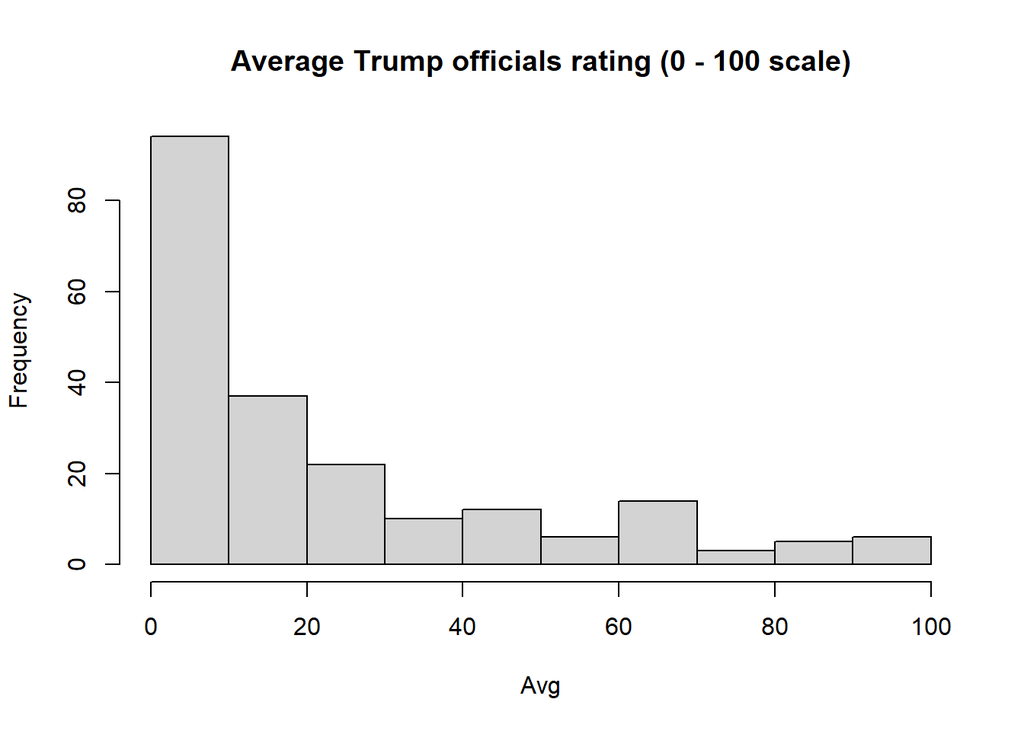

```r
hist(pilot$avg_nominees, main='Average Trump officials rating (0 - 100 scale)', xlab ='Avg')
```

Now we can take a look at the relationship between party ID and average thermometer ratings:

```r
compmeansC(dv= avg_nominees,  iv=party_id, data=pilot,
           xlab = 'Party ID',
           ylab = 'Average thermometer',
           main = 'Average Trump admin. official rating (0 - 100 scale)',
           plot=FALSE
           )
```

```
===========================================================================
                         Mean Comparison Analysis
===========================================================================


Table: Mean Values of avg_nominees by party_id

                               Mean     N   St. Dev.
---------------------------  ------  ----  ---------
Strong Democrat               10.82    79      14.98
Not very strong Democrat      19.00    43      20.21
Independent Democrat          12.14    28      16.50
Independent                   23.76    19      22.58
Independent Republican        55.20    16      22.49
Not very strong Republican    52.10    14      32.43
Strong Republican             70.51    10      21.46
Total                         22.88   209      26.25
```

# Checking missing values

Generally, missing data in R will be represented as `NA` values. Running use `is.na(x)` will return `TRUE` if an observation is missing and `FALSE` if the observation is not missing.

If you use a numeric function on a logical value in R, `TRUE` values will get converted to 1 and `FALSE` values will get converted to 0. So if we wanted to know how many missing responses we had for Question 9, we could just `sum` the results of `is.na(pilot$Q9)` :

```r
sum(is.na(pilot$Q9))
```

```
[1] 23
```

What we do with this information is another question entirely, but having lots of missing data can pose issues for your analyses.

# Assessing a relationship

I’m going to look at how responses to Q52 (belief that social media has a negative impact), on responses to (support for the forced sale of TikTok). My hypothesis is that people who believe social media is harmful will be more likely to support the forced sale. Since both these outcomes are categorical, I’m going to use a crosstab to explore the relationship.

After analyzing my basic descriptive statistics for each variable, I conclude that it makes sense to collapse some of the response categories together to simplify my analysis and to get around the problem of cells with very few observations (only three people said social media had an “Extremely positive” effect!).

So I collapse the responses to both questions to create dichotomous variables for each item:

```r
# making a dichotomous variable for
pilot$sm_negative <- factor(pilot$Q52,
                            ordered =TRUE,
                            labels = c("Negative", "Negative", "Not negative", "Not negative",  "Not negative"))

pilot$tiktok_ban <- factor(pilot$Q8,
                           ordered = TRUE,
                           labels = c("Opposed","Opposed","Opposed","Not opposed", "Not opposed", "Not opposed", "Not opposed"))
```

Then I’ll create a cross tab so I can look at the effect of `sm_negative` on supporting the TikTok ban:

```r
# Is there a relationship here?
crosstabC(dv = tiktok_ban,
          iv = sm_negative,
          data=pilot,
          plot = FALSE,
          compact =TRUE # removes the raw counts row (slightly more readable table)

          )
```

```
===========================================================================
                         Cross-Tabulation Analysis
===========================================================================


Table: Cross-Tabulation of tiktok_ban and sm_negative

                 Negative   Not negative   Totals
--------------  ---------  -------------  -------
% Opposed           52.57          69.51    57.98
% Not opposed       47.43          30.49    42.02
Count              175.00          82.00   257.00
```

Remember that the way we read this output is by looking at the difference across each level of the IV. So the effect of believing Social media has a negative impact relative to believing it has a non-negative impact is a $52.57 - 69.51 = -16.94$ percentage point decrease in opposition to the TikTok ban.

### Controlled comparison

There’s a zero-order relationship between my IV and DV, but there’s a chance that its spurious: perhaps the reason for the observed relationship is that people who don’t use social media are both more likely to think it is harmful and more likely to support banning it. To rule out this possibility, we’ll use responses to Q50, which asks how often respondents use social media to get news. Once again, we’re going to combine some categories to simplify the analysis: we’ll split up the responses to this question in to “Every day” and “Less than every day”:

```r
pilot$daily_sm <- factor(pilot$Q50 == "Daily",
                                 ordered =TRUE,
                         labels = c("Less than every day", "Every day")
)
```

Then we’ll create out controlled cross tab and assess the results:

```r
# Is there a relationship here?
crosstabC(dv = tiktok_ban,
          iv = sm_negative,
          z = daily_sm,
          data=pilot,
          plot = FALSE,
          compact = TRUE
          # removes the raw counts row (slightly more readable table)

          )
```

```
===========================================================================
                   Controlled Cross-Tabulation Analysis
===========================================================================


Table: Cross-Tabulation of tiktok_ban and sm_negative, controlling for daily_sm

                 Less than every day: Negative   Not negative   Every day: Negative   Not negative   | Totals
--------------  ------------------------------  -------------  --------------------  -------------  ---------
% Opposed                                50.00          67.74                 58.82          75.00      57.98
% Not opposed                            50.00          32.26                 41.18          25.00      42.02
Count                                   124.00          62.00                 51.00          20.00     257.00
```

Our effect is still present, the direction of the effect is the same at both levels of the control, and the strength of the effect is only very slightly different. Given these results, it appears the relationship here is additive: both social media use and views of social media’s impact on society independently influence support for a TikTok ban.

# Saving data

In general, I recommend that you save your code rather than trying to save data itself, but if you do want to have a local copy of the pilot data that you can alter as needed, you can save an R object by entering `saveRDS(object, file='filename.rds')`. For example:

```r
saveRDS(pilot, file='my_pilot_copy.rds')
```

Then, to restore the data, you would just load it back in by using the `readRDS` function:

```r
pilot_data <-readRDS('my_pilot_copy.rds')
```

## Footnotes

[^1]: The :: in `Hmisc::label` is a way to use a function from a package without having to load the entire package with the `library` function. You’ll typically see this when we just need to use one function from a package, or when the function shares a name with a function from another package.